# Module 7: Strategy Development & Regional Coordination

Somali Fish Stock Training - Led by TAFIRI

Author

Tanzania Fisheries Research Institute & Somali Partners

Published

December 10, 2025

```r
require(sf)
require(tidyverse)
require(sizeMat)
require(gt)
require(tidyplots)
require(patchwork)
require(leaflet)
```

## Welcome to Module 7

**Strategy Development & Regional Coordination**

### Learning Objectives

- Develop long-term monitoring strategy
- Build regional coordination mechanisms
- Integrate across all 6 regions
- Engage policy makers
- Create sustainable systems

### Led By: TAFIRI

- Tanzania Fisheries Research Institute
- 30+ years experience
- Regional expertise
- Capacity building focus
- Sustainable solutions

## TAFIRI Expertise & Role

### Tanzania Fisheries Research Institute:

- **Founded**: 1980s
- **Mission**: Fisheries research for sustainable development
- **Experience**: Lake Victoria, Indian Ocean, coastal fisheries
- **Expertise**: Stock assessment, data systems, training
- **Regional Role**: Supporting East African fisheries capacity
- **Best Practice**: Lessons from Tanzania applied to Somalia

## Why Regional Coordination Matters

### The Challenge:

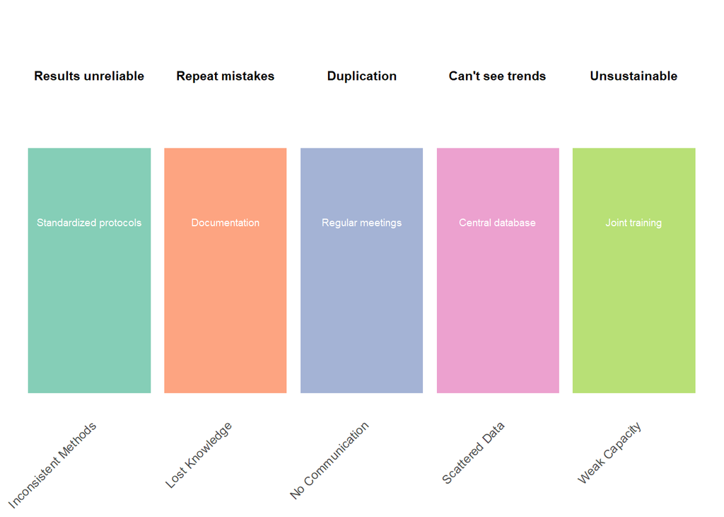

## Vision: A Unified Somali Fisheries System

### By 2027:

**Somalia has:** - Coordinated monitoring at all 6 regions - Standardized data collection protocols - Real-time data sharing system - Monthly regional assessments - Quarterly national reports - Active policy integration - Trained workforce of 30+ analysts - Sustainable funding mechanism

## Current State Assessment

### Regional Capacity Snapshot:

Current Regional Fisheries Monitoring Status

Baseline for coordination planning

| Region | Data Collection | Analysis Capacity | Infrastructure | Status |
| --- | --- | --- | --- | --- |
| Berbera | Good | Moderate | Adequate | Operational |
| Borama | Moderate | Limited | Poor | Starting |
| Mogadishu | Good | Good | Good | Operational |
| Kismayo | Limited | Limited | Poor | Needs Support |
| Baidoa | Limited | Limited | Poor | Needs Support |
| Galkacyo | Minimal | Minimal | Very Poor | Needs Support |

## Regional Coordination Structure

### Proposed Governance Model:

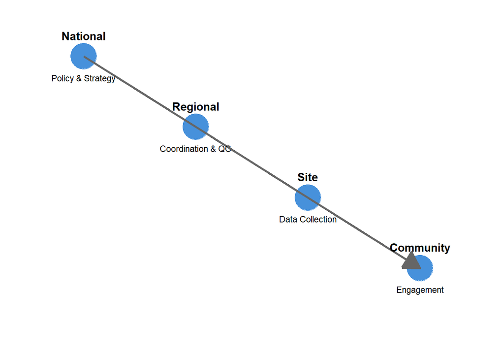

## National Fisheries Monitoring Committee

### Proposed Structure:

**Members:** - Ministry of Fisheries (Chair) - TAFIRI representative - Regional coordinators (6) - Community representatives (3) - Academic institutions (2) - International partners (2)

**Functions:** - Set national strategy - Approve protocols - Review quarterly reports - Coordinate funding - Recommend policies

## National Committee: Responsibilities

### Strategic Functions:

**Policy Integration** - Link data to regulations - Advise on catch limits - Support management decisions - Report to government

**Quality Assurance** - Approve protocols - Review data quality - Recommend improvements - Audit processes

**Resource Mobilization** - Identify funding sources - Manage budget - Coordinate donors - Plan sustainability

**Capacity Building** - Approve training programs - Support professional development - Share best practices - Build regional networks

## Regional Coordination Teams

### Six Regional Teams (One per Landing Site Hub):

**Composition:** - Regional Coordinator (FTE) - Data Manager (50%) - Community Liaison (50%) - Technical support from TAFIRI

**Responsibilities:** - Monthly data collection - Quality control checks - Database management - Quarterly reporting - Community engagement

## Regional Coordinator Role

### Job Description:

```r
# POSITION: Regional Fisheries Monitoring Coordinator
#
# QUALIFICATIONS:
# - Diploma/degree in fisheries, biology, or related field
# - Experience in data collection preferred
# - Fluent in Somali and English
# - Computer literacy
# - Strong communication skills
#
# KEY RESPONSIBILITIES:
# 1. Oversee monthly data collection at landing sites
# 2. Maintain database and backup systems
# 3. Conduct monthly data analysis
# 4. Prepare quarterly reports
# 5. Lead community engagement activities
# 6. Implement quality assurance procedures
# 7. Support TAFIRI training activities
# 8. Attend quarterly national meetings
#
# PERFORMANCE METRICS:
# - Data quality: >95% complete, <2% error rate
# - Timeliness: All reports on schedule
# - Coverage: All sites monitored monthly
# - Stakeholder satisfaction: >80% positive feedback
```

## Standardized Protocols Across Regions

### Universal Data Collection Standard:

```r
# File structure all regions must follow
standardized_template <- list(
  data = list(
    landing_date = "YYYY-MM-DD",
    region = "One of 6 regions",
    landing_site = "Specific site name",
    fish_group = "Standard taxonomy",
    length_cm = "Numeric, ±0.1cm",
    weight_kg = "Numeric, ±0.1kg",
    metadata = list(
      observer = "Name",
      sampler_id = "Unique ID",
      effort = "Landing count",
      notes = "Any issues"
    )
  ),
  quality_checks = list(
    range_validation = "Length 5-200cm, Weight 0.1-500kg",
    completeness = "No missing critical fields",
    timeliness = "Entered within 24 hours",
    duplication = "No exact duplicates"
  ),
  reporting = list(
    monthly = "By 5th of following month",
    quarterly = "By 15th of quarter start",
    annual = "By end of Q1 next year"
  )
)
```

## Central Database System

### National Data Repository:

**Architecture:**

```
┌─────────────────────────────────┐
│   National Database (Cloud)      │
│   - PostgreSQL backend           │
│   - Real-time sync               │
│   - Backup & disaster recovery   │
└────────┬────────────────────────┘
         │
    ┌────┴────┬────────┬────────┬────────┬─────────┐
    │          │        │        │        │         │
  Berbera   Borama  Mogadishu Kismayo Baidoa  Galkacyo
  (Local)   (Local)  (Local)  (Local) (Local)  (Local)
```

**Features:** - Regional databases sync to national - Real-time dashboards - Automated quality checks - Role-based access control - Audit trails & versioning

## Data Sharing & Access Protocols

### Information Governance:

**Public Access** - Aggregated data - Annual reports - Policy briefs - General statistics

**Restricted Access** - Individual fisher data - Site-specific reports - Quality audit details - Sensitive locations

**Professional Access** - Raw data (authorized) - Monthly reports - Analysis tools - Training materials

**Policy Maker Access** - Management briefings - Stock status summaries - Recommendation documents - Regular reporting

## Monthly Regional Assessment Process

### Standardized Workflow:

Monthly Assessment Calendar

Standardized timing across all regions

| week | activity | lead |
| --- | --- | --- |
| Week 1 | Data collection at sites | Field team |
| Week 2 | Data entry & cleaning | Data manager |
| Week 3 | Analysis & visualization | Coordinator |
| Week 4 | Regional report & review | Coordinator + TAFIRI |

## Quarterly National Coordination Meeting

### Face-to-Face Regional Reporting:

**Participants:** - 6 Regional Coordinators - National Committee members - TAFIRI representatives - 2-3 policy advisors

**Agenda (2 days):**

**Day 1:** - Morning: Regional presentations (40 min each) - Afternoon: Data quality review - Evening: Strategy discussion

**Day 2:** - Morning: Problem-solving workshops - Afternoon: Capacity building session - Closing: Action items & planning

## Quarterly Reporting Format

### Standardized National Report:

**Note**

## Integration with Policy Makers

### Translating Data to Policy:

```r
# Example: How data informs management decisions

# Data insight
mean_length_declining <- data |>
  group_by(year) |>
  summarise(mean_L = mean(length_cm)) |>
  pull(mean_L) |>
  diff() < 0  # Negative trend

# Policy implications
if (mean_length_declining) {

  recommendations <- c(
    "Consider reducing catch limits by 10%",
    "Implement minimum size regulations",
    "Restrict access to juvenile habitat",
    "Monitor recruitment closely",
    "Engage fishers in co-management"
  )

  return(recommendations)
}
```

## Policy Integration Workshops

### Quarterly Engagement Sessions:

**Participants:** - Ministry of Fisheries officials - Regional administrators - Fishing community leaders - International advisors

**Format:** - Morning: Data presentations - Afternoon: Facilitated discussion - Output: Policy recommendations

**Topics Cycle:** - Q1: Stock status & catch limits - Q2: Regional equity & access - Q3: Community concerns - Q4: Annual strategy review

## Capacity Building Strategy

### Three-Year Development Plan:

**Year 1 (Foundational):** - All 6 regional coordinators trained (this program) - Establish protocols & databases - First 12 months baseline data - Build management committee

**Year 2 (Expansion):** - Train 18-24 field technicians - Implement full regional monitoring - Establish data management systems - Link to policy processes

**Year 3 (Sustainability):** - Local training by coordinators - Full regional independence - Secure funding mechanisms - Regional networks established

## Training Cascade Model

### Who Trains Whom:

```
┌──────────────────────────────────┐
│  TAFIRI (International experts)  │
│  Trains:                         │
├──────────────────────────────────┤
│  6 Regional Coordinators         │
│  (This program)                  │
│  Train:                          │
├──────────────────────────────────┤
│  18-24 Field Technicians         │
│  (Year 2 training)               │
│  Train/Support:                  │
├──────────────────────────────────┤
│  Community Monitors              │
│  (Ongoing capacity)              │
└──────────────────────────────────┘
```

## Funding Strategy & Sustainability

### Multi-Source Funding Model:

**Government Budget** - Core staff (coordinators) - National office operations - Equipment maintenance

**International Donors** - Training programs - Database development - Regional workshops

**Private Sector** - Fishing company sponsorship - Equipment suppliers - Service providers

**Community Contributions** - Landing fee allocation - Volunteer support - Local resources

## Financial Projections

### Annual Budget Estimate:

```r
# Rough annual budget (USD) for complete system

budget <- tibble(
  Category = c(
    "Staff (6 regional coordinators @ $12k/yr)",
    "National coordinator & office",
    "Training & workshops",
    "Database & IT systems",
    "Equipment & supplies",
    "Travel & meetings",
    "Contingency (10%)"
  ),
  Amount = c(72000, 25000, 15000, 20000, 10000, 8000, 15000)
)

budget |>
  mutate(
    Total = sum(Amount),
    `% of Budget` = round(Amount / Total * 100, 1)
  ) |>
  gt() |>
  fmt_currency(columns = Amount, currency = "USD") |>
  opt_stylize(style = 6, color = 'gray')
```

[output not shown]

## Sustainability Beyond Funding

### Building Independence:

**By Year 3:** - Regional coordinators run programs - Local training capacity developed - Systems operate with minimal external support - Donor funds transition to catalytic role - National government assumes core funding

**Key Success Factors:** - Strong local ownership - Demonstrated policy impact - Community support - Trained successor generation - Documented procedures

## Risk Management & Contingency

### Potential Challenges:

**Political Risk** - Solution: Multi-stakeholder governance - Backup: International support

**Technical Risk** - Solution: Redundant systems - Backup: Manual procedures

**Staff Turnover** - Solution: Training pipeline - Backup: Documentation

**Funding Gaps** - Solution: Diversified sources - Backup: Scaled-down operations

**Data Quality Issues** - Solution: QC procedures - Backup: External audits

**Infrastructure Failures** - Solution: Cloud backup - Backup: Offline capability

## Monitoring & Evaluation Framework

### Track Progress Toward Goals:

```r
# KPIs to monitor system health

kpis <- tibble(
  KPI = c(
    "Data completeness",
    "Reporting timeliness",
    "Regional participation",
    "Committee meetings",
    "Policy integration",
    "Staff retention",
    "Stakeholder satisfaction"
  ),
  Target = c("95%", "100%", "100%", "100%", "High", ">90%", ">80%"),
  Measurement = c(
    "Monthly audit",
    "Check dates",
    "Regional reports",
    "Meeting records",
    "Policy actions",
    "Annual review",
    "Annual survey"
  ),
  Frequency = c(
    "Monthly",
    "Monthly",
    "Monthly",
    "Quarterly",
    "Annual",
    "Annual",
    "Annual"
  )
)
```

## Communication & Outreach Strategy

### Multi-Level Messaging:

**For Policy Makers:** - Stock status updates - Management recommendations - Risk assessments - Quarterly briefings

**For Fishing Communities:** - Local monitoring results - Seasonal updates - Management implications - Feedback opportunities

**For International Partners:** - Technical reports - Progress updates - Success stories - Lessons learned

## Regional Success Stories

### Model Sites to Highlight:

**Berbera Region:** - Mature monitoring program - Strong commercial interest - Good data quality - Policy linkages developing

**Mogadishu Region:** - Urban fisheries focus - High landing volumes - Growing capacity - Research partnerships

**Emerging Successes:** - Community engagement improving - Data quality consistent - Staff retention stable - Policy interest growing

## Lessons from TAFIRI Experience

### Applied to Somalia:

1. **Start with committed partners** - Not every region ready simultaneously
2. **Build incrementally** - Small successes lead to bigger support
3. **Invest in people** - Staff development > equipment spending
4. **Document everything** - Procedures survive staff turnover
5. **Maintain data integrity** - QC is continuous, not final
6. **Link to policy** - Data only valuable if used
7. **Engage communities** - Fishers are essential partners
8. **Plan for sustainability** - Think beyond project duration

## Technology Considerations

### Which Tools for Which Purpose:

**Data Collection:** - ✓ Mobile apps with offline capability - ✓ Paper forms (backup) - ✗ Complex systems (infrastructure limited)

**Data Management:** - ✓ Cloud database (PostgreSQL) - ✓ Automated backups - ✗ Complex local servers

**Analysis:** - ✓ R & RMarkdown (free, powerful) - ✓ Simple tools (Excel acceptable) - ✗ Expensive licensed software

**Reporting:** - ✓ Interactive dashboards (Shiny) - ✓ Static reports (PDF/HTML) - ✓ Paper reports (where needed)

## Implementation Timeline

### Year-by-Year Roadmap:

**2024 (Current) - Foundation:** - Complete Module 1-6 training (6 coordinators) - Establish national committee - Develop protocols & database structure - Begin baseline data collection

**2025 - Expansion:** - Train field technicians - Full monitoring at 6 regional hubs - Launch central database - Monthly regional assessments

**2026 - Integration:** - Policy integration accelerates - Community programs mature - Quarterly national reports - Adaptive management cycle

## Year-by-Year Roadmap (continued)

**2027 - Sustainability:** - Regional independence established - Local training capacity proven - Secure funding mechanisms - System operates smoothly

**2028+ - Growth:** - Additional monitoring sites - Expanded species coverage - Regional network development - International partnerships

## Stakeholder Engagement Plan

### Who to Engage When:

**Immediate (Month 1-3):** - National government - Regional administrations - Training participants

**Short-term (Month 3-12):** - Fishing communities - Landing site managers - Academic institutions

**Medium-term (Year 2):** - International NGOs - Donor organizations - Policy forums

**Long-term (Year 3+):** - Regional networks - IOTC coordination - Conservation organizations

## Advocacy & Policy Influence

### How Data Informs Policy:

```
Data Collection
      ↓
Regional Assessment
      ↓
National Synthesis
      ↓
Policy Briefing
      ↓
Management Decision
      ↓
Implementation
      ↓
Effectiveness Monitoring
      ↓ (feedback loop)
```

## International Coordination

### Regional Context - East African Fisheries:

**IOTC (Indian Ocean Tuna Commission):** - Somalia is member state - Stock assessment requirements - Data submission deadlines - Capacity building support

**SWIOFC (Southwest Indian Ocean Fisheries Commission):** - Regional coordination - Best practices sharing - Joint research initiatives

**Bilateral Partnerships:** - Kenya, Tanzania, Mozambique - Experience exchange - Coordinated monitoring

## Research Partnerships

### Leveraging Scientific Capacity:

**With Universities:** - Student training opportunities - Research collaborations - Thesis supervision - Technology transfer

**With Research Institutions:** - TAFIRI (ongoing support) - Other African institutes - International centers - Joint projects

**With NGOs:** - Capacity building support - Conservation initiatives - Community programs - Resource support

## Adaptive Management Cycle

### Using Data to Improve Fisheries:

```
Year 1-2: Establish baseline
      ↓
Year 2-3: Identify trends
      ↓
Year 3-4: Propose management changes
      ↓
Year 4-5: Implement & monitor effectiveness
      ↓
Year 5+: Refine & optimize
      ↓ (continuous loop)
```

## Strategic Challenges & Solutions

### Key Issues to Address:

**Political Will:** - Challenge: Competing priorities - Solution: Demonstrate data value

**Funding Security:** - Challenge: Limited national budget - Solution: Diversify funding sources

**Technical Capacity:** - Challenge: Limited expertise - Solution: Sustained training & mentoring

**Community Buy-in:** - Challenge: Skepticism about benefits - Solution: Early results & transparent sharing

## Success Metrics - How We’ll Know

### Qualitative Indicators:

- Strong regional team cohesion
- Visible community support
- Growing policy integration
- Improved data quality
- Documented lessons learned
- Mentor-mentee relationships

## Conclusion: Transformation Vision

### Somalia’s Fisheries Future:

By 2027, Somalia will have:

✓ Evidence-based fisheries management ✓ Coordinated regional monitoring ✓ Sustainable research capacity ✓ Community-engaged governance ✓ Data-driven policy decisions ✓ International recognition ✓ Regional network leadership

## Key Takeaways

### Module 7 Summary:

1. Regional coordination essential for scale
2. Standardized protocols enable comparison
3. Central database serves all stakeholders
4. Clear governance structure needed
5. Sustainability requires diverse funding
6. Capacity building is long-term investment
7. Policy integration is critical success factor
8. Community engagement builds support
9. TAFIRI experience informs best practices
10. Success is achievable with commitment

## Your Role in Strategy Implementation

### As Trained Coordinators, You Will:

- Lead regional monitoring programs
- Implement standardized protocols
- Manage regional databases
- Conduct quarterly assessments
- Engage fishing communities
- Present policy recommendations
- Train field technicians
- Mentor junior staff
- Contribute to national strategy
- Build professional networks

## Next Steps After Module 7

### The Journey Forward:

**Immediate (Next 3 months):** 1. Establish national committee 2. Finalize protocols 3. Set up database infrastructure 4. Assign regional coordinators 5. Plan first monitoring cycle

**Short-term (Next 12 months):** 6. Begin baseline data collection 7. Conduct first quarterly meeting 8. Train field technicians 9. Establish database operations 10. Generate first regional reports

## Commitment & Accountability

### Personal Action Plans:

Each participant should develop:

1. **Your Regional Vision** (2027)
   - What does success look like?
   - What’s your role?
   - What resources needed?
2. **Your First Year Goals**
   - What will you accomplish?
   - Who will you work with?
   - How will you measure success?
3. **Your Support Needs**
   - What training do you need?
   - What equipment?
   - What partnerships?

## Questions & Regional Discussions

### Group Reflections:

- What excites you about this vision?
- What concerns do you have?
- What barriers exist in your region?
- How will you build support?
- What’s your first priority?
- Who are your key partners?

## Closing Remarks from TAFIRI

### The Path Forward:

**“Building sustainable fisheries monitoring systems requires:**

- Patience and persistence
- Strong partnerships
- Commitment to quality
- Community engagement
- Data integrity
- Realistic timelines
- Local ownership

**The work is challenging, but the impact is profound.**

**You have the knowledge, support, and motivation to succeed.**

**Tanzania’s experience shows it’s possible. Somalia can do it too.”**

— TAFIRI Leadership

## Final Certification

### Participants Who Complete All 7 Modules:

**Receive Certificate of Competency in:** - Fisheries Stock Assessment - Data Collection & Management - Regional Coordination - Evidence-Based Fisheries Management

**Qualified to:** - Lead monitoring programs - Manage fisheries data systems - Conduct stock assessments - Advise on management policies - Train other staff members

## Resource Materials Provided

### You Take Away:

- Complete training manual (all 7 modules)
- Standardized data collection forms
- R scripts for analysis
- Database setup templates
- Communication templates
- Safety & field protocols
- Reference materials & contacts
- Digital copies of all presentations

## Ongoing Support Commitment

### TAFIRI Support Available:

- **Quarterly consultations** via video conference
- **Annual in-person visit** per region
- **Email support** for technical questions
- **Peer networking** with other East African programs
- **Advanced training** on demand
- **Joint research opportunities**
- **Publication support**

**Long-term partnership, not a one-time project**

## Contact & Continuation

### Key Contacts:

**Regional Coordinators:** Contact list by region (provided separately)

## Congratulations!

### You Have Completed:

- ✓ **Module 1**: Fundamentals & Concepts
- ✓ **Module 2**: Data Collection Protocols
- ✓ **Module 3**: Data-Limited Methods
- ✓ **Module 4**: Data Processing & Storage
- ✓ **Module 5**: Data Analysis Methods
- ✓ **Module 6**: Field Exercises
- ✓ **Module 7**: Strategy Development

## What Comes Next:

### Transition to Implementation:

**Weeks 1-4:** Establish national committee & begin coordination **Months 2-6:** Set up infrastructure & train technicians **Months 6-12:** Launch full regional monitoring **Year 2+:** Integrate into policy & expand coverage

## Thank You

**Somali Fish Stock Training Program**

**Module 7: Strategy Development & Regional Coordination**

**Led By: Tanzania Fisheries Research Institute (TAFIRI)**

*Building sustainable evidence-based fisheries management*

*For the people and waters of Somalia*

## Final Reflection

### Your Impact:

The data you collect The analyses you conduct The decisions you influence The communities you engage

Will determine the future of fisheries in Somalia.

**This is important work.**

**You are ready.**

**Go make a difference.**

## Session Evaluation

### Please Complete:

Feedback survey covering: - Learning effectiveness - Relevance to your work - Trainer quality - Facilities & logistics - Materials & resources - Confidence to implement - Support needs going forward - Overall satisfaction

Your feedback helps us improve the program.

## Certification Handover

### Official Ceremony:

Each participant receives: - Certificate of Competency - Regional assignment letter - Contact directory - Resource package - Support commitment letter

**Signed by:** - TAFIRI Director - Somali Fisheries Ministry - Training Program Lead

## One More Thing…

### The Journey Doesn’t End Here

**Note**

This training is the beginning, not the end.

Real learning happens in the field, in your communities, in your data.

The skills you’ve learned need to be applied, adapted, and improved continuously.

The network you’ve built is your strongest asset.

The commitment you make today will shape fisheries management in Somalia for decades.

**Stay connected. Keep learning. Lead boldly.**

## Thank You for Your Commitment

**Somali Fish Stock Training Program**

*Empowering Evidence-Based Fisheries Management*

**October 2024 - January 2025**

Questions? Contact TAFIRI or your regional coordinator.

**Welcome to the team.**